# GE 461 Introduction to Data Science

Statistical Models by Savaş Dayanık

#### Week 5: Advertising and Promotion

The Dodgers is a professional baseball team and plays in the Major Baseball League. The team owns a 56,000-seat stadium and is interested in increasing the attendance of their fans during home games.*At the moment the team management would like to know if bobblehead promotions increase the attendance of the team’s fans?* This is a case study based on Miller (2014 Chapter 2).

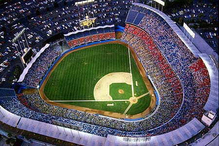

[figure not shown]

[figure not shown]

Figure 1: 56,000-seat Dodgers stadium (left), shirts and caps (middle), bobblehead (right)

```r
include_graphics(c("los_angeles-dodgers-stadium.jpg",
                 "Los-Angeles-Dodgers-Promo.jpg",
                 "adrian_bobble.jpg"))
```

The 2012 season data in the `events` table of SQLite database `data/dodgers.sqlite` contain for each of 81 home play the

- month,
- day,
- weekday,
- part of the day (day or night),
- attendance,
- opponent,
- temperature,
- whether cap or shirt or bobblehead promotions were run, and
- whether fireworks were present.

## Prerequisites

We will use `R`, `RStudio`, `R Markdown` for the next three weeks to fit statistical models to various data and analyze them. Read Wickham and Grolemund (2017) online

- [Section 1.1](https://r4ds.had.co.nz/introduction.html#prerequisites) for how to download and install `R` and `RStudio`,
- [Chapter 27](https://r4ds.had.co.nz/r-markdown.html) for how to use `R Markdown` to interact with `R` and conduct various predictive analyses.

All materials for the next three weeks will be available on [Google drive](https://drive.google.com/drive/folders/1ehZI2fF7awKOBik7YSuAbyGV7Sa2jOj_?usp=sharing).

## March 1: Exploratory data analysis

1. Connect to `data/dodgers.sqlite`. Read table `events` into a variable in `R`.
   - Read Baumer, Kaplan, and Horton (2017, Chapters 1, 4, 5, 15) ([Second edition online](https://mdsr-book.github.io/mdsr2e/)) for getting data from and writing them to various SQL databases.
   - Because we do not want to hassle with user permissions, we will use SQLite for practice. I recommend `PostgreSQL` for real projects.
   - Open `RStudio` terminal, connect to database `dodgers.sqlite` with `sqlite3`. Explore it (there is only one table, `events`, at this time) with commands
     - `.help`
     - `.databases`
     - `.tables`
     - `.schema <table_name>`
     - `.headers on`
     - `.mode column`
     - `SELECT ...`
     - `.quit`
   - Databases are great to store and retrieve large data, especially, when they are indexed with respect to variables/columns along with we do search and match extensively.
   - `R` (likewise, `Python`) allows one to seeminglessly read from and write to databases. For fast analysis, keep data in a database, index tables for fast retrieval, use `R` or `Python` to fit models to data.

```r
# Ctrl-shift-i
#library(RPostgreSQL)
library(RSQLite)  ## if package is not on the computer, then install it only once using Tools > Install packages...
con <- dbConnect(SQLite(), "../data/dodgers.sqlite") # read Modern Data Science with R for different ways to connect a database.

## dbListTables(con)

events <- tbl(con, "events") %>%
  collect() %>%
  mutate(day_of_week = factor(day_of_week, levels = c("Monday", "Tuesday", "Wednesday", "Thursday", "Friday", "Saturday", "Sunday")),
         month = factor(month, levels = c("APR","MAY","JUN","JUL","AUG","SEP","OCT")))

# events %>% distinct(month)
# events$day_of_week %>% class()
# events$day_of_week %>% levels()
# events
```

2. What are the number of plays on each week day and in each month of a year?
3. Check the orders of the levels of the `day_of_week` and `month` factors. If necessary, put them in the logical order.
4. How many times were bobblehead promotions run on each week day?
5. How did the attendance vary across week days? Draw boxplots. On which day of week was the attendance the highest on average?
6. Is there an association between attendance and
   - whether the game is played in day light or night?
   - Between attendance and whether skies are clear or cloudy?
7. Is there an association between attendance and temperature?
   - If yes, is there a positive or negative association?
   - Do the associations differ on clear and cloud days or day or night times?

## Next time: A linear regression model

Regress attendance on `month`, `day of the week`, and `bobblehead` promotion.

8. Is there any evidence for a relationship between attendance and other variables? Why or why not?
9. Does the bobblehead promotion have a statistically significant effect on the attendance?
10. Do month and day of week variables help to explain the number of attendants?
11. How many fans are expected to be drawn alone by a bobblehead promotion to a home game? Give a 90% confidence interval.
12. How good does the model fit to the data? Why? Comment on residual standard error and R$^2$. Plot observed attendance against predicted attendance.
13. Predict the number of attendees to a typical home game on a Wednesday in June if a bobblehead promotion is extended. Give a 90% prediction interval.

## Project (will be graded)

Include **all variables** and conduct a full regression analysis of the problem. Submit your `R markdown` and `html` files to course homepage on moodle.

## Bibliography

Baumer, B. S., D. T. Kaplan, and N. J. Horton. 2017. *Modern Data Science with R*. Chapman & Hall/CRC Texts in Statistical Science. CRC Press. https://books.google.com.tr/books?id=NrddDgAAQBAJ.

Miller, T. W. 2014. *Modeling Techniques in Predictive Analytics with Python and R: A Guide to Data Science*. FT Press Analytics. Pearson Education. https://books.google.com.tr/books?id=PU6nBAAAQBAJ.

Wickham, H., and G. Grolemund. 2017. *R for Data Science*. O’Reilly Media. https://books.google.com.tr/books?id=aZRYrgEACAAJ.